# Lab 3

Mia Raghavan, Julie Jung, Dion Ho, Vincent Fung

06/09/2019

# Exercise 1

*Read in the CSV file cs-training-NAs-removed.csv which is posted with this lab on Canvas.*

```r
data <- read.csv("cs-training-NAs-removed.csv")
```

The dataset consists information about each person that can possibly be used to predict whether that person will experience financial distress in the next two years - and hence whether that person is credit worthy.

# Exercise 2

*What is in the first column of the data frame that you created by reading in the CSV file? Do you expect this variable to be useful to predict credit worthiness?*

```r
head(data[,1])
```

```
## [1] 1 2 3 4 5 6
```

The first column consists of the index of each person in the dataset. Since the index was assigned arbitrarily and is interchangable between persons, it is not useful in predicting the credit worthiness of a person.

# Exercise 3

*Fit a logistic regression with SeriousDlqin2yrs as dependent variable and MonthlyIncome as the only predictor. Interpret the estimated parameter for MonthlyIncome in plain English. Is the sign (positive versus negative) of this parameter estimate as you would have expected beforehand?*

```r
logit <- glm(data$SeriousDlqin2yrs ~ data$MonthlyIncome, family=binomial)
summary(logit)
```

```
##
## Call:
## glm(formula = data$SeriousDlqin2yrs ~ data$MonthlyIncome, family = binomial)
##
## Deviance Residuals:
##     Min       1Q   Median       3Q      Max
## -0.4330  -0.4005  -0.3813  -0.3531   5.2293
##
## Coefficients:
##                      Estimate Std. Error z value Pr(>|z|)
## (Intercept)        -2.320e+00  2.007e-02 -115.61   <2e-16 ***
## data$MonthlyIncome -4.541e-05  2.917e-06  -15.57   <2e-16 ***
## ---
## Signif. codes:  0 '***' 0.001 '**' 0.01 '*' 0.05 '.' 0.1 ' ' 1
##
## (Dispersion parameter for binomial family taken to be 1)
##
##     Null deviance: 60689  on 120268  degrees of freedom
## Residual deviance: 60391  on 120267  degrees of freedom
## AIC: 60395
##
## Number of Fisher Scoring iterations: 6
```

For every increase in the monthly income of a person by 1 unit, the log-odds decreases by 4.541e-05, where the probability is that of a person experiencing financial distress in the next two years.

The negative sign indicates that a person with a greater monthly income will have a lower probability of experiencing financial distress in the next two years. The negative sign is expected and makes intuitive sense.

# Exercise 4

*Consider the model fit from Exercise 3. Create a side-by-side boxplot of the predicted probabilities seperated out by whether the person actually had a serious delinquency (SeriousDlqin2yrs==1) or not. What do you think of the usefulness of this model fit to determine credit worthiness?*

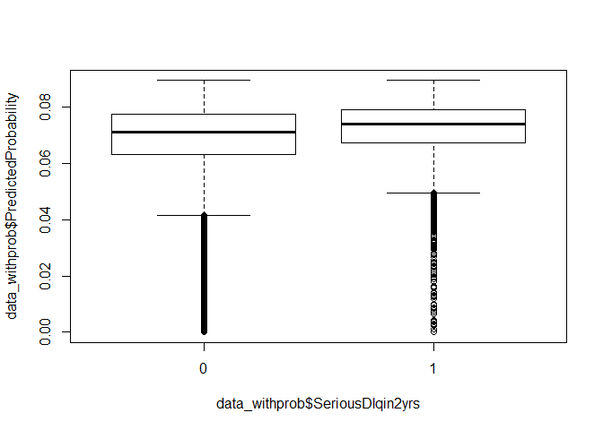

```r
data_withprob <- data
data_withprob$PredictedProbability <- predict(logit, type="response")
boxplot(data_withprob$PredictedProbability ~ data_withprob$SeriousDlqin2yrs)
```

The two box plots are very similar which indicates a massive overlap in the distribution of probabilities for those who had a serious delinquency and those who did not. The median for the group of people who had a serious delinquency have a slightly higher median and interquartile range, but this difference is not very clear from these boxplots. Therefore, the model is not very useful as it does not distinguish well between the two groups which makes it likely that it will misclassify many people.

# Exercise 5

*Consider the side-by-side boxplots from Exercise 4. Define SeriousDlqin2yrs == 1 as a positive. Using a probability threshold of 0.5 for classification, how many true positives would you get? How many false positives would you get? How many true negatives will you get? How many false negatives will you get?*

```r
all(data_withprob$PredictedProbability<0.5)
```

```
## [1] TRUE
```

```r
summary(data$SeriousDlqin2yrs == 1)
```

```
##    Mode   FALSE    TRUE
## logical  111912    8357
```

Since the predicted probability is less than the probability threshold of 0.5 for every person, every person is predicted to not experience financial distress in the next two years. Since we have 0 positives, we have 0 true or false positives. We have 8357 false negatives, which are simply the 1s in the dataset, and we have 111912 true negatives, which are the 0s in the dataset.

# Exercise 6

*Plot the ROC curve of the model fit from Exercise 4 and compute the corresponding area under the curve (AUC). Do these results support the answer that you give in Exercise 4 to the question “What do you think of the usefulness of this model fit to determine credit worthiness?” Please explain why or why not.*

```r
library(ROCR)
```

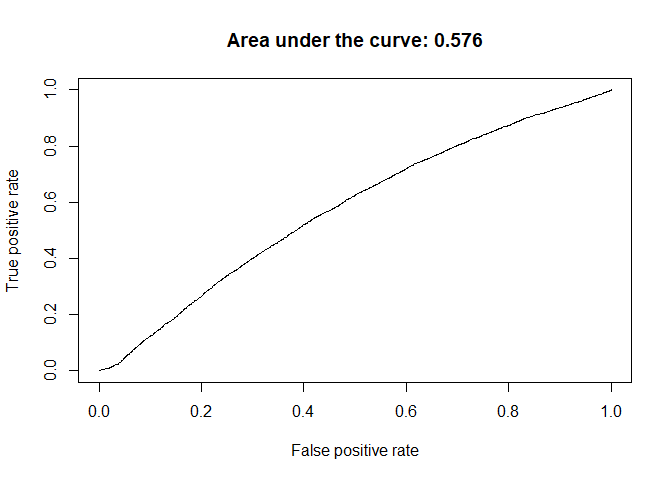

```r
predObj = prediction(data_withprob$PredictedProbability, data_withprob$SeriousDlqin2yrs)
rocObj = performance(predObj, measure="tpr", x.measure="fpr")
aucObj = performance(predObj, measure="auc")
plot(rocObj, main = paste("Area under the curve:",
round(aucObj@y.values[[1]] ,4)))
```

We want our model to have an AUC which is close to 1 as that indicates that there exist probability thresholds which allow for good classification: low false positive rate and high true positive rate. The model we have however, has an AUC of 0.576 which is very far from 1 and closer to 0.5, which is the expected AUC if we had used coin flips to decide the classification. This supports our belief that the model is not useful.

# Exercise 7

*Fit a logistic regression with SeriousDlqin2yrs as dependent variable and as predictor all other variables in the dataset. Plot the ROC curve and compute the AUC. How do the ROC curve and AUC compare to the results from Exercise 6? Was this to be expected? Why or why not?*

```r
logit_all <- glm(SeriousDlqin2yrs ~ ., data = data, family=binomial)
data_withprob2 <- data
data_withprob2$PredictedProbability <- predict(logit_all, type="response")
data_withoutX <- subset(data, select = -X)
logit_all<-glm(SeriousDlqin2yrs~., data = data_withoutX, family=binomial)
```

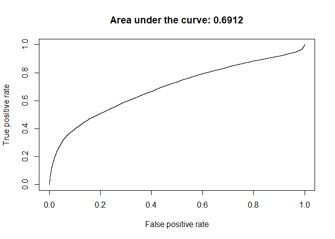

```r
data_withprob2<-data_withoutX
data_withprob2$PredictedProbability<-predict(logit_all, type="response")
predObj = prediction(data_withprob2$PredictedProbability, data_withprob$SeriousDlqin2yrs)
rocObj = performance(predObj, measure="tpr", x.measure="fpr")
aucObj = performance(predObj, measure="auc")
plot(rocObj, main = paste("Area under the curve:",
                          round(aucObj@y.values[[1]] ,4)))
```

The AUC is now 0.6912 which is greater than the original 0.576 and closer to 1. This indicates that the model can now be used to make better classifications. This is to be expected since the model is drawing upon more data to decide on the classifications (since we added more predictors). The increase in the AUC indicates that the additional predictors are indeed correlated to the outcome.

# Exercise 8

*In linear regression, the coefficients are determined by minimizing the sum of the squared residuals. Give a conceptual description of how the coefficients are determined for the logistic regression fit from the previous exercise.*

To determine the coefficients for the logistic regression fit in an analogous method to the least squares method is to use the Maximum Likelihood Estimation (MLE) method. Define a likelihood function that takes the coefficients of the logistic regression model, $\vec{w}$, and the predictors, $\vec{x_n}$, as some of its paramaters and outputs the probability that an event, $t_n$, otherwise known as ground truth, is observed. Suppose that the events are independent, then we can multiply the probability functions together to get a function which tells us the probability that we made the observations, $\vec{t}$, given $\vec{w}$, a matrix of predictors, $X$, and possibly other parameters. Finally, we maximise the all-data-likelihood function, or more often the log of the function (the result is the same), with respect to $\vec{w}$. The optimal $\vec{w}$, often denoted $\vec{w}^*$, are the coefficients we use for the logistic regression fit. Other, arguably better, methods are the Maximum A Posteriori estimation (MAP) and the Full Bayesian method.